# gender in Lezgic and beyond

Rita Popova

2023-06-27

```r
library(tidyverse)
library(caret)
library(pROC)
library(readxl)
library(jtools)
library(randomForest)
library(stringi)
```

## Outline of the project

Some East Caucasian languages feature 4-value gender systems: gender 1 is for male referents, gender 2 is for female referents and genders 3 & 4 are for the rest. Human genders show transparent assignment rules, assignment of nouns to non-human genders is opaque.

In this project, I want to explore a few factors that are potentially meaningful for assignment to Gender 3 and Gender 4. It could be the case, that special rules of assignment operate over:

- loanwords
- compounds
- words that start with some particular phoneme
- words that denote things which are remarkably small
- words that denote things which are remarkably large

I test the data of 4-gendered Lezgic languages (Archi, Rutul, Tsakhur, Budukh and Kryz) and two 4-gendered languages which are not Lezgic but are heavily-influenced by Lezgic.

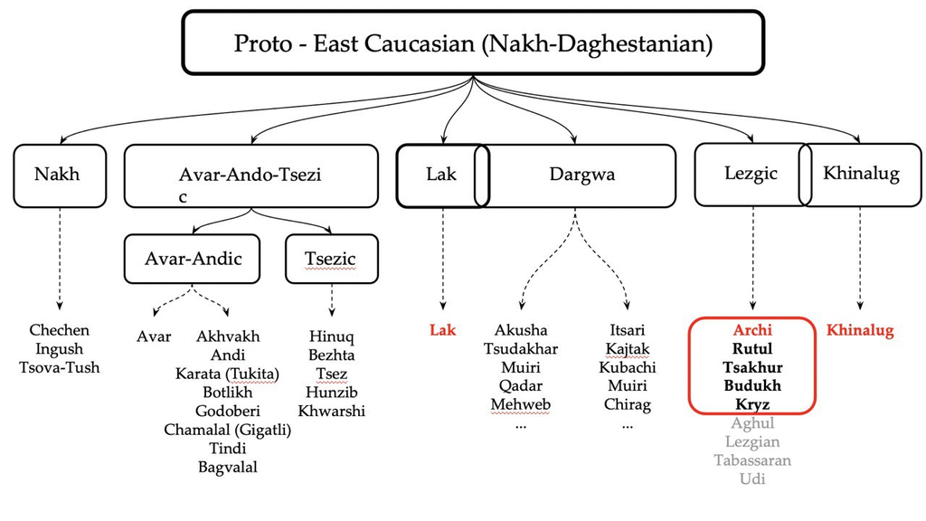

eastcaucasia.png

I will first run **chi-square** test to see if any of the factors above and gender values are not independent.

Then, I run **LogReg** and **Random Forest****.

In the end, I plot RocAuc to see which of the two methods above perform better.

## Data

The data consists of:

- a list of concepts where each of the meanings is annotated as being Large of Small; built along the lines of Conceptual Properties Norming studies (Popova, Buzanov, Daniel & Voloshina in prep.)
- translation equivalents for these concepts in 7 languages
- annotation of words: first phoneme, loanwords, compounds, gender values

#### Mapping concepts to words

```r
big.concepts <- read_excel("big itog.xlsx")
small.concepts <- read_excel("small itog.xlsx")

big.concepts %>%
  filter(`MA&R FREQ` > 0) -> big.concepts #filter out the concepts collected experimentally by collegues and me
small.concepts %>%
  filter(`MA&R FREQ` > 0) -> small.concepts
```

```r
big.concepts$size <- "BIG" #tag concepts as either Big or Small
small.concepts$size <- "SMALL"

concepts <- bind_rows(big.concepts, small.concepts) #now we store 'concepts' as one file
```

Big and Small things split in half in our dataset:

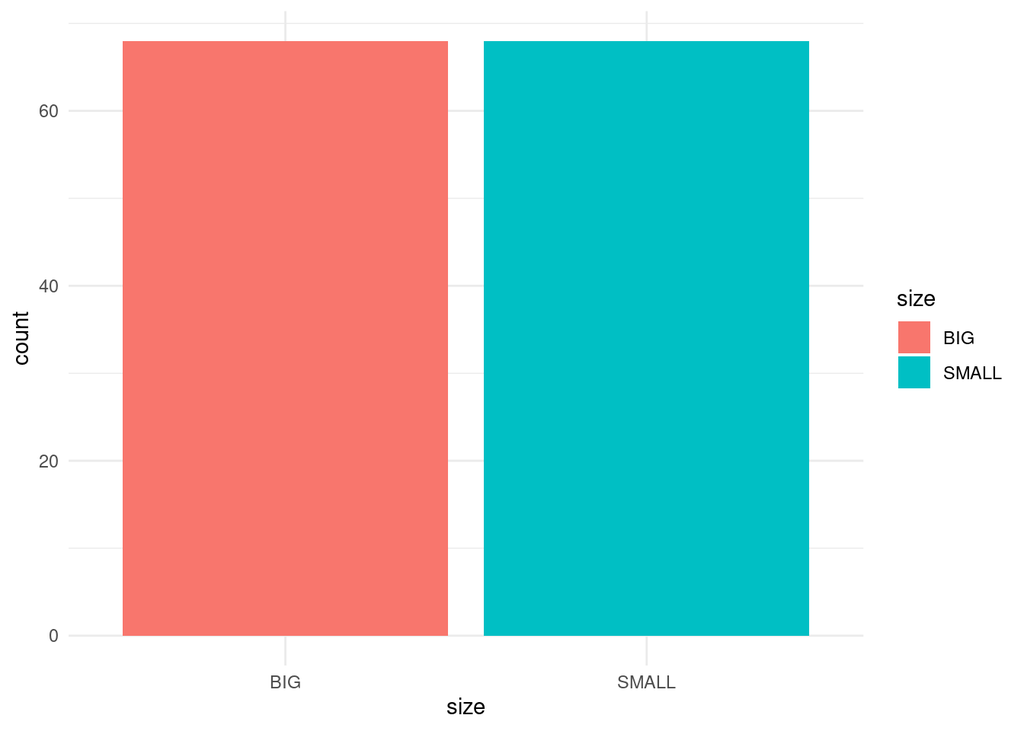

```r
concepts %>%
  ggplot(aes(size, fill=size)) +
    geom_bar() +
    theme_minimal()
```

```r
words <- data.frame()

for (lang in c("archi", "lak", "tsakhur", "rutul",
               "budukh", "kryz", "khinalug")) {
  df <- read_excel(
    sprintf(
      "%s revised may.xlsx", lang # these are 7 excel files with words from 7 languages and annotation
    )
  )

  df$language <- lang
  df$gender <- as.character(df$gender)

  words <- bind_rows(words, df) # assign translation equivalents to all the concepts on the list, extract gender values
}
```

```r
words %>%
  filter(gender %in% c("3", "4")) %>%
  mutate(gender = as.numeric(gender)) -> words #getting rid of the noise, leaving only words which are either gender 3 or gender 4
```

```r
merge(concepts, words, by = "concept") %>%
  select(size, gender, `f compound`, `f loan`,
         russian.x, language, concept, word) %>%
  replace(is.na(.), "no") -> data #add annotation of compounds and loans, indicate which items are neither compounds nor loans.
```

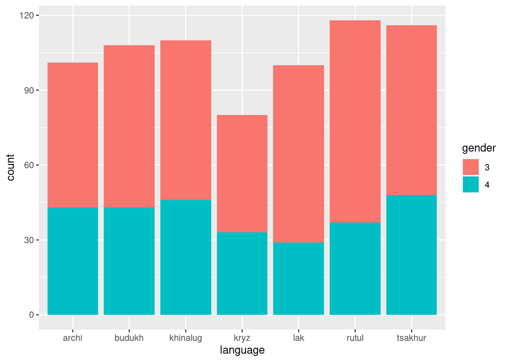

```r
data %>%
  ggplot(aes(language, fill=as.character(gender))) +
    geom_bar() +
    labs(fill = "gender")
```

#### First phoneme annotation

```r
data %>%
  mutate(word = stri_trans_general(tolower(word), "cyrillic-latin"),
         first_ph = substr(word, 1, 1)
  ) -> data #lowercase, translitirate, pick out the first symbol
```

```r
unique(data$first_ph)
```

```
##  [1] "z" "n" "k" "d" "m" "p" "b" "č" "ç" "s" "χ" "c" "t" "g" "v" "l" "š" "q" "j"
## [20] "a" "i" "o" "f" "ʕ" "h" "ş" "u" "r" "w" "y" "ɬ" "ž" "â" "ë" "x"
```

```r
mapping <- c(
  z="fric", n="ant", k="plos", d="ant", m="lab", p="lab",
  b="lab", č="ant", ç="ant", s="ant", χ="fric", c="ant",
  t="ant", g="plos", v="lab", l="liq", š="ant", q="plos",
  j="ant", a="vow", i="vow", o="vow", f="fric", ʕ="fric",
  h="fric", ş="fric", u="vow", r="liq", w="lab", y="vow",
  ɬ="liq", ž="ant", â="vow", ë="vow", x="fric"
) #annotating possible first phonemes as either fricative, anterior, labial, plosive, liquid or vowel
```

```r
data %>%
  mutate(first_ph_class = mapping[first_ph]) -> data #adding annotation to the data
```

#### Compounds and Loans: are they even present in the data?

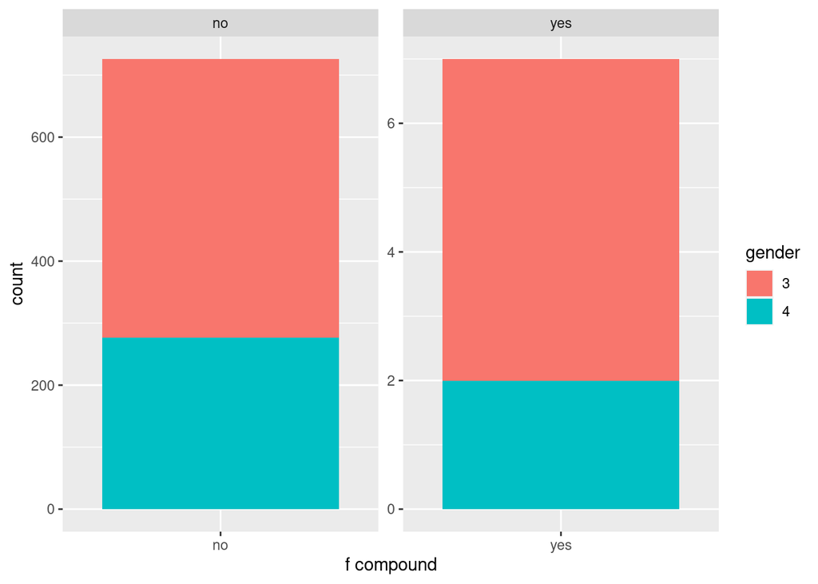

```r
data %>%
  ggplot(aes(`f compound`, fill=as.character(gender)))+
    geom_bar() +
    facet_wrap(~`f compound`, scales="free") +
    labs(fill="gender")
```

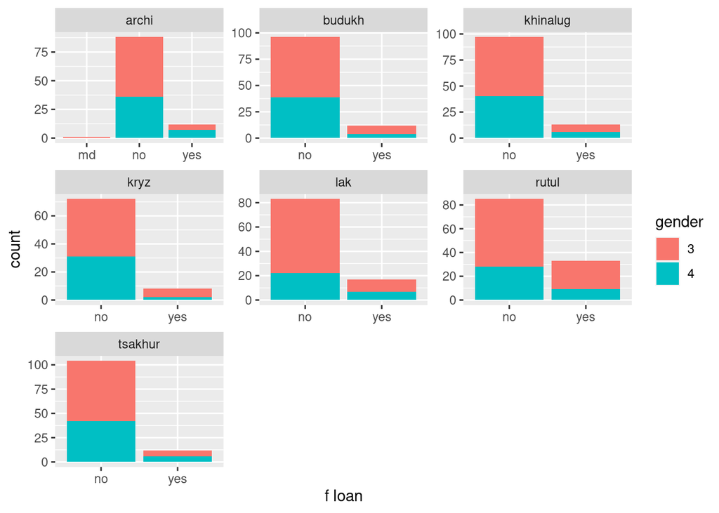

```r
data %>%
  ggplot(aes(`f loan`, fill=as.character(gender)))+
    geom_bar() +
    facet_wrap(~language, scales="free") +
    labs(fill="gender")
```

## Chi-sqaure

### Chi-square test: loanwords

No skewing!

```r
for (lang in unique(data$language)) {
  data %>%
    filter(language == lang) -> df

    res <- chisq.test(df$gender, df$`f loan`)

    print(sprintf("%s language: p-value = %s", lang, res$p.value))
}
```

```
## [1] "archi language: p-value = 0.356981737340814"
## [1] "kryz language: p-value = 0.544760062426277"
## [1] "tsakhur language: p-value = 0.740753660744096"
## [1] "khinalug language: p-value = 0.969604946208917"
## [1] "rutul language: p-value = 0.707917277266041"
## [1] "lak language: p-value = 0.356996902759043"
## [1] "budukh language: p-value = 0.862064716070069"
```

### Chi-square test: first phoneme class

No skewing!

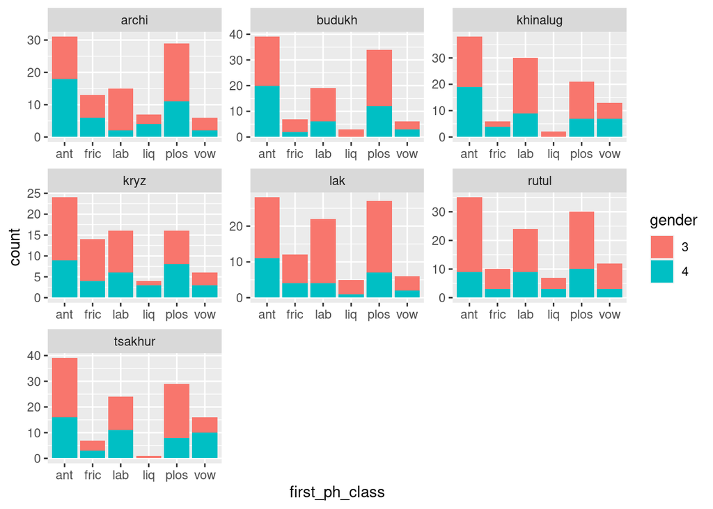

```r
data %>%
  ggplot(aes(first_ph_class, fill=as.character(gender)))+
    geom_bar() +
    facet_wrap(~language, scales="free") +
    labs(fill="gender")
```

```r
for (lang in unique(data$language)) {
  data %>%
    filter(language == lang) -> df

    res <- chisq.test(df$gender, df$first_ph_class)

    print(sprintf("%s language: p-value = %s", lang, res$p.value))
}
```

```
## [1] "archi language: p-value = 0.0931119114033321"
## [1] "kryz language: p-value = 0.588039791730091"
## [1] "tsakhur language: p-value = 0.294019937162713"
## [1] "khinalug language: p-value = 0.211711203683792"
## [1] "rutul language: p-value = 0.894279957855289"
## [1] "lak language: p-value = 0.673188205277653"
## [1] "budukh language: p-value = 0.349080269486381"
```

### Chi-square test: size

No skewing!!! :(

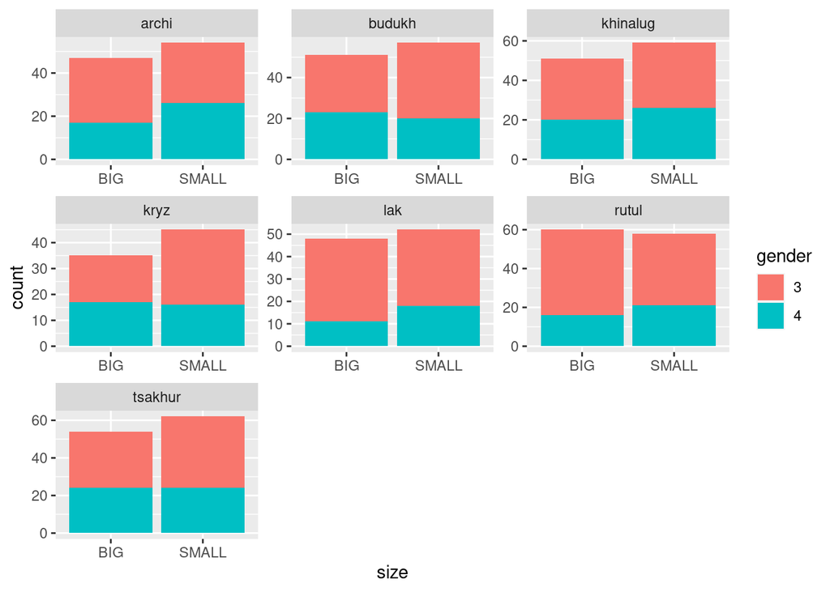

```r
data %>%
  ggplot(aes(size, fill=as.character(gender)))+
    geom_bar() +
    facet_wrap(~language, scales="free") +
    labs(fill="gender")
```

```r
for (lang in unique(data$language)) {
  data %>%
    filter(language == lang) -> df

    res <- chisq.test(df$gender, df$size)

    print(sprintf("%s language: p-value = %s", lang, res$p.value))
}
```

```
## [1] "archi language: p-value = 0.311243801744263"
## [1] "kryz language: p-value = 0.345046612807637"
## [1] "tsakhur language: p-value = 0.662414397068881"
## [1] "khinalug language: p-value = 0.748460816309355"
## [1] "rutul language: p-value = 0.35847724018793"
## [1] "lak language: p-value = 0.285749421234879"
## [1] "budukh language: p-value = 0.387551760591273"
```

## LogReg results

Apparently, the only meaningful factor which helps predicting gender value is **bi-liabial inital phoneme** for **Archi** and **Lak**. If the word starts with [p], [b], or [m] it is likely to belong to Gender 3.

```r
for (lang in unique(data$language)) {
  data %>%
    filter(language == lang) -> df

  fit <- glm(data=df, as.factor(gender) ~ size + first_ph_class + `f loan`,
             family = "binomial")

  cat("-----------\n")
  cat(lang)
  cat("\n-----------\n\n\n")
  print(summ(fit))

  pred_proba <- predict(fit, df, type = "response")

  cm <- confusionMatrix(as.factor(as.numeric(pred_proba>0.5) + 3), as.factor(df$gender))
  cat("\n\n\n\n")
  print(cm)
  cat("\n\n\n\n")
}
```

```
## -----------
## archi
## -----------
##
##
## MODEL INFO:
## Observations: 101
## Dependent Variable: as.factor(gender)
## Type: Generalized linear model
##   Family: binomial
##   Link function: logit
##
## MODEL FIT:
## χ²(8) = 17.89, p = 0.02
## Pseudo-R² (Cragg-Uhler) = 0.22
## Pseudo-R² (McFadden) = 0.13
## AIC = 137.89, BIC = 161.42
##
## Standard errors: MLE
## -----------------------------------------------------------
##                              Est.      S.E.   z val.      p
## ------------------------ -------- --------- -------- ------
## (Intercept)                -15.19   1455.40    -0.01   0.99
## sizeSMALL                    0.67      0.47     1.42   0.16
## first_ph_classfric          -0.43      0.69    -0.62   0.54
## first_ph_classlab           -2.79      0.96    -2.90   0.00
## first_ph_classliq           -0.44      0.90    -0.49   0.63
## first_ph_classplos          -1.05      0.57    -1.86   0.06
## first_ph_classvow           -1.63      1.03    -1.58   0.11
## f loan`no                   15.15   1455.40     0.01   0.99
## f loan`yes                  16.88   1455.40     0.01   0.99
## -----------------------------------------------------------
##
##
##
##
## Confusion Matrix and Statistics
##
##           Reference
## Prediction  3  4
```

[output cut: 404 more lines]

```
##                   Kappa : 0.1116
##
##  Mcnemar's Test P-Value : 0.001194
##
##             Sensitivity : 0.8462
##             Specificity : 0.2558
##          Pos Pred Value : 0.6322
##          Neg Pred Value : 0.5238
##              Prevalence : 0.6019
##          Detection Rate : 0.5093
##    Detection Prevalence : 0.8056
##       Balanced Accuracy : 0.5510
##
##        'Positive' Class : 3
##
```

## Random Forest: results

```
##
##
##
##
## Confusion Matrix and Statistics
##
##           Reference
## Prediction  3  4
##          3 27  7
##          4 31 36
##
##                Accuracy : 0.6238
##                  95% CI : (0.5218, 0.7182)
##     No Information Rate : 0.5743
##     P-Value [Acc > NIR] : 0.1828541
##
##                   Kappa : 0.2823
##
##  Mcnemar's Test P-Value : 0.0001907
##
##             Sensitivity : 0.4655
##             Specificity : 0.8372
##          Pos Pred Value : 0.7941
##          Neg Pred Value : 0.5373
##              Prevalence : 0.5743
##          Detection Rate : 0.2673
##    Detection Prevalence : 0.3366
##       Balanced Accuracy : 0.6514
##
##        'Positive' Class : 3
##
```

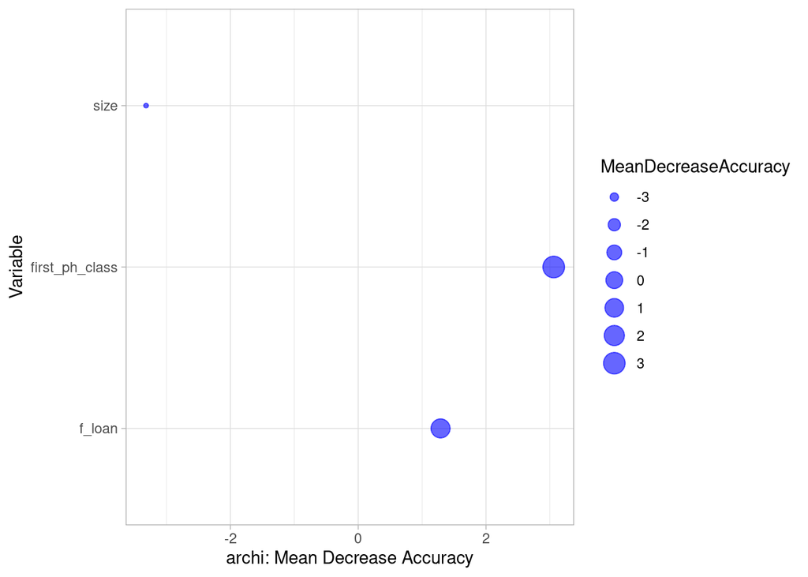

```
##
##
##
##
## Confusion Matrix and Statistics
##
##           Reference
## Prediction  3  4
##          3 39 21
##          4  8 12
##
##                Accuracy : 0.6375
##                  95% CI : (0.5224, 0.7421)
##     No Information Rate : 0.5875
##     P-Value [Acc > NIR] : 0.21415
##
##                   Kappa : 0.2055
##
##  Mcnemar's Test P-Value : 0.02586
##
##             Sensitivity : 0.8298
##             Specificity : 0.3636
##          Pos Pred Value : 0.6500
##          Neg Pred Value : 0.6000
##              Prevalence : 0.5875
##          Detection Rate : 0.4875
##    Detection Prevalence : 0.7500
##       Balanced Accuracy : 0.5967
##
##        'Positive' Class : 3
##
```

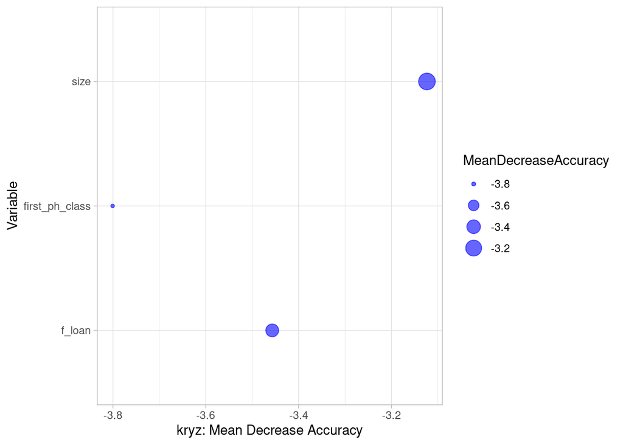

```
##
##
##
##
## Confusion Matrix and Statistics
##
##           Reference
## Prediction  3  4
##          3 62 35
##          4  6 13
##
##                Accuracy : 0.6466
##                  95% CI : (0.5524, 0.7331)
##     No Information Rate : 0.5862
##     P-Value [Acc > NIR] : 0.1096
##
##                   Kappa : 0.2004
##
##  Mcnemar's Test P-Value : 1.226e-05
##
##             Sensitivity : 0.9118
##             Specificity : 0.2708
##          Pos Pred Value : 0.6392
##          Neg Pred Value : 0.6842
##              Prevalence : 0.5862
##          Detection Rate : 0.5345
##    Detection Prevalence : 0.8362
##       Balanced Accuracy : 0.5913
##
##        'Positive' Class : 3
##
```

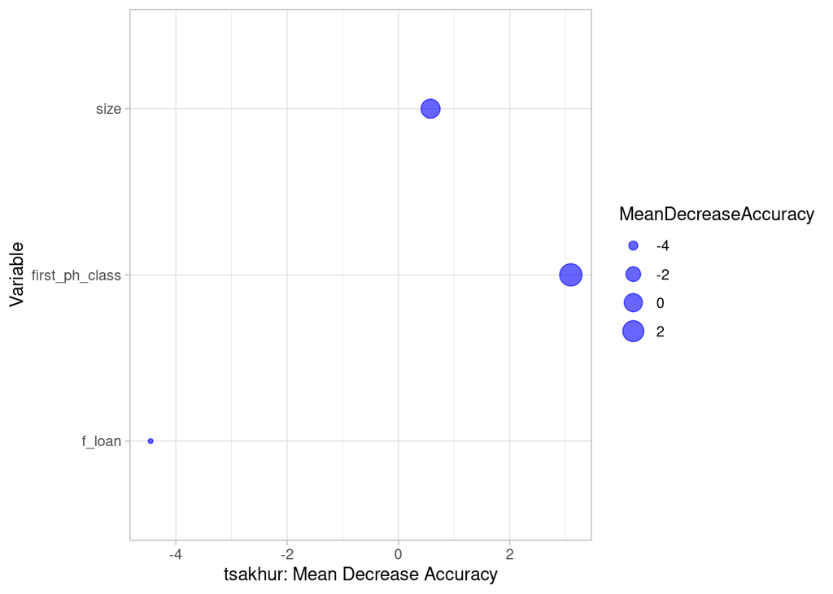

```
##
##
##
##
## Confusion Matrix and Statistics
##
##           Reference
## Prediction  3  4
##          3 47 21
##          4 17 25
##
##                Accuracy : 0.6545
##                  95% CI : (0.5579, 0.7426)
##     No Information Rate : 0.5818
##     P-Value [Acc > NIR] : 0.07256
##
##                   Kappa : 0.2813
##
##  Mcnemar's Test P-Value : 0.62650
##
##             Sensitivity : 0.7344
##             Specificity : 0.5435
##          Pos Pred Value : 0.6912
##          Neg Pred Value : 0.5952
##              Prevalence : 0.5818
##          Detection Rate : 0.4273
##    Detection Prevalence : 0.6182
##       Balanced Accuracy : 0.6389
##
##        'Positive' Class : 3
##
```

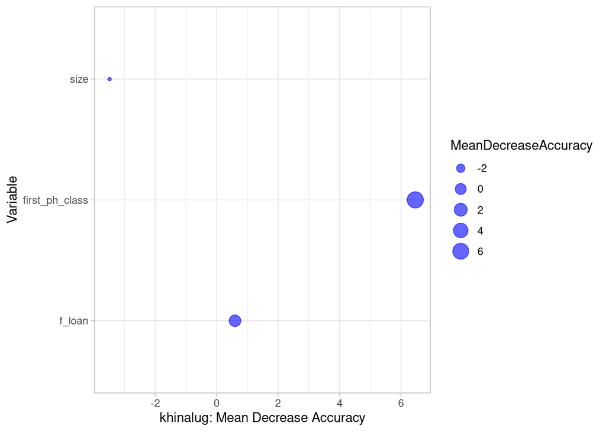

```
##
##
##
##
## Confusion Matrix and Statistics
##
##           Reference
## Prediction  3  4
##          3 81 37
##          4  0  0
##
##                Accuracy : 0.6864
##                  95% CI : (0.5946, 0.7687)
##     No Information Rate : 0.6864
##     P-Value [Acc > NIR] : 0.5443
##
##                   Kappa : 0
##
##  Mcnemar's Test P-Value : 3.252e-09
##
##             Sensitivity : 1.0000
##             Specificity : 0.0000
##          Pos Pred Value : 0.6864
##          Neg Pred Value :    NaN
##              Prevalence : 0.6864
##          Detection Rate : 0.6864
##    Detection Prevalence : 1.0000
##       Balanced Accuracy : 0.5000
##
##        'Positive' Class : 3
##
```

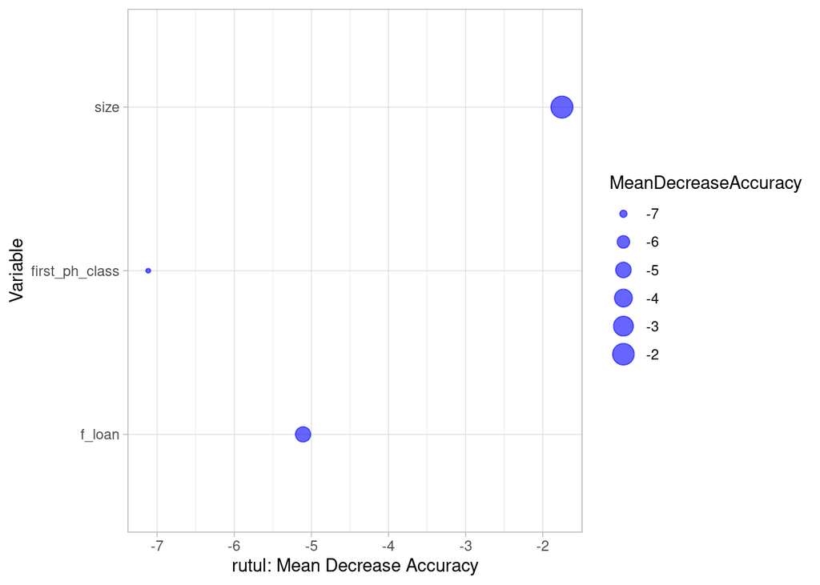

```
##
##
##
##
## Confusion Matrix and Statistics
##
##           Reference
## Prediction  3  4
##          3 71 27
##          4  0  2
##
##                Accuracy : 0.73
##                  95% CI : (0.632, 0.8139)
##     No Information Rate : 0.71
##     P-Value [Acc > NIR] : 0.3758
##
##                   Kappa : 0.0952
##
##  Mcnemar's Test P-Value : 5.624e-07
##
##             Sensitivity : 1.00000
##             Specificity : 0.06897
##          Pos Pred Value : 0.72449
##          Neg Pred Value : 1.00000
##              Prevalence : 0.71000
##          Detection Rate : 0.71000
##    Detection Prevalence : 0.98000
##       Balanced Accuracy : 0.53448
##
##        'Positive' Class : 3
##
```

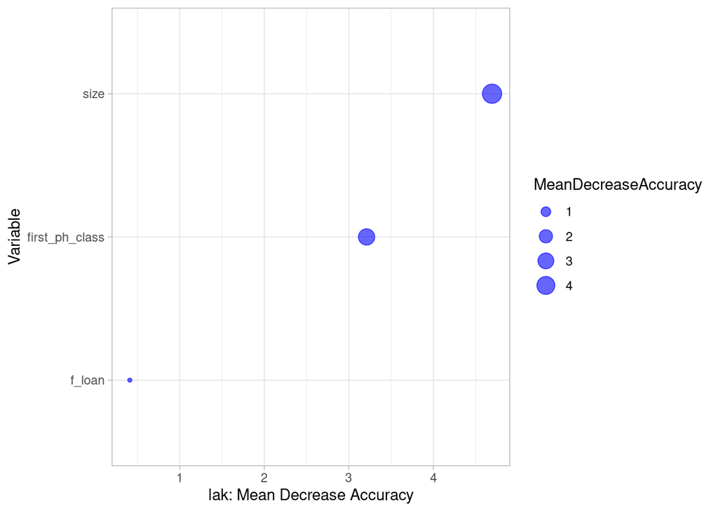

```
##
##
##
##
## Confusion Matrix and Statistics
##
##           Reference
## Prediction  3  4
##          3 45 19
##          4 20 24
##
##                Accuracy : 0.6389
##                  95% CI : (0.5408, 0.7291)
##     No Information Rate : 0.6019
##     P-Value [Acc > NIR] : 0.2469
##
##                   Kappa : 0.2495
##
##  Mcnemar's Test P-Value : 1.0000
##
##             Sensitivity : 0.6923
##             Specificity : 0.5581
##          Pos Pred Value : 0.7031
##          Neg Pred Value : 0.5455
##              Prevalence : 0.6019
##          Detection Rate : 0.4167
##    Detection Prevalence : 0.5926
##       Balanced Accuracy : 0.6252
##
##        'Positive' Class : 3
##
```

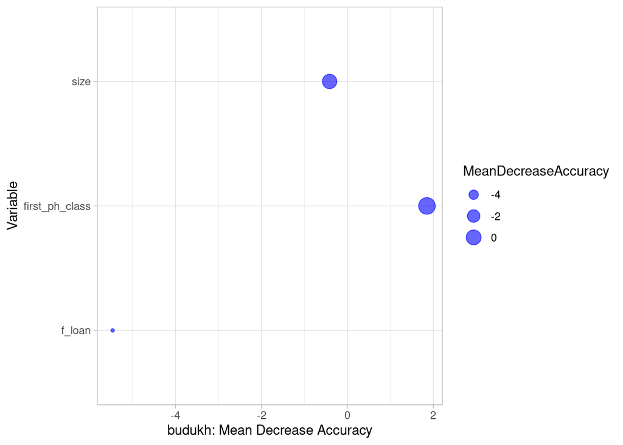

```r
for (lang in unique(data$language)) {
  data %>%
    filter(language == lang) -> df

  names(df) <- str_replace(names(df), " ", "_")

  model.forest <- randomForest(data=df,
                               as.factor(gender) ~ size + first_ph_class + f_loan,
                               importance = TRUE)

  pred_proba <- predict(model.forest, df, type="prob")
  pred_proba <- as_tibble(pred_proba)$`4`

  cm <- confusionMatrix(as.factor(as.numeric(pred_proba>0.3) + 3), as.factor(df$gender))
  cat("\n\n\n\n")
  print(cm)
  cat("\n\n\n\n")

  importance.forest <- as.data.frame(importance(model.forest))
  importance.forest$vars <- row.names(importance.forest)


  ggplot(importance.forest, aes(x=vars, y=MeanDecreaseAccuracy)) +
    geom_point(aes(size = MeanDecreaseAccuracy), color="blue", alpha=0.6) +
    xlab("Variable") +
    ylab(sprintf("%s: Mean Decrease Accuracy", lang)) +
    theme_light() +
    coord_flip() -> g

  plot(g)
}
```

## ROC AUC: results

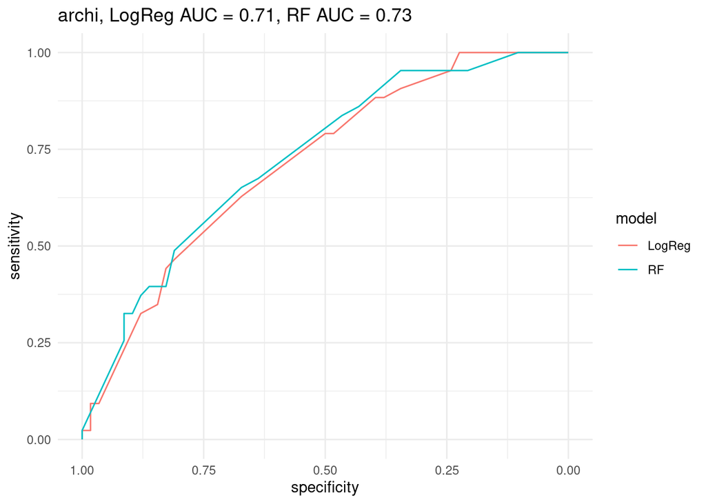

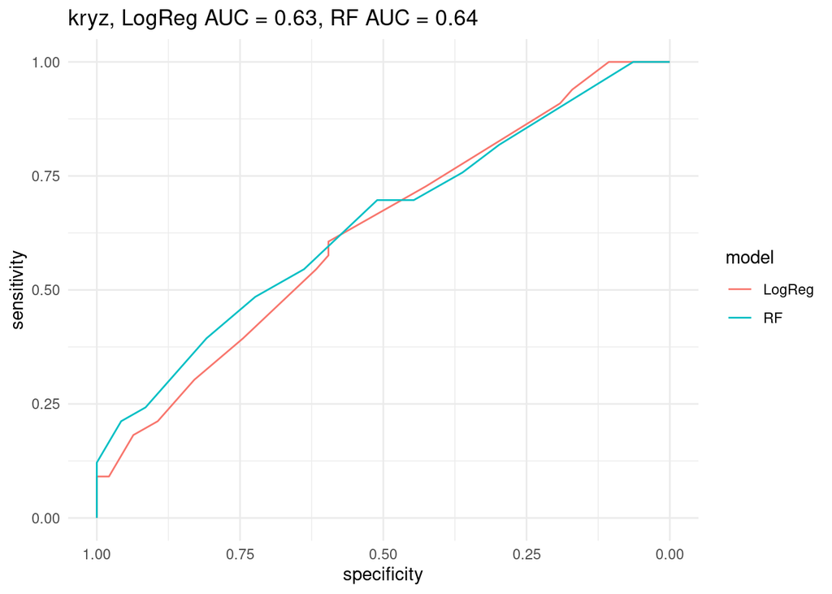

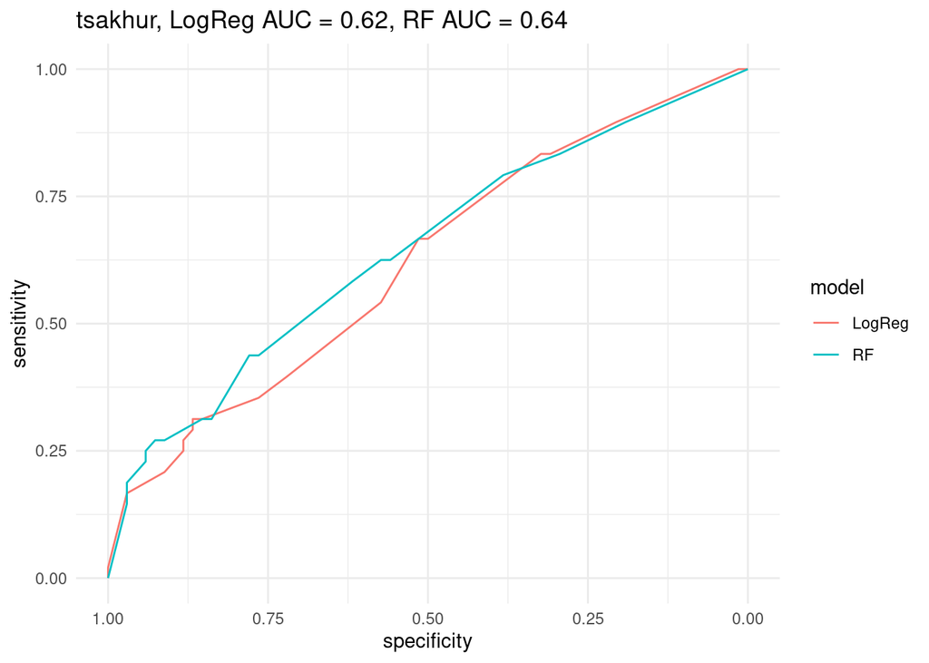

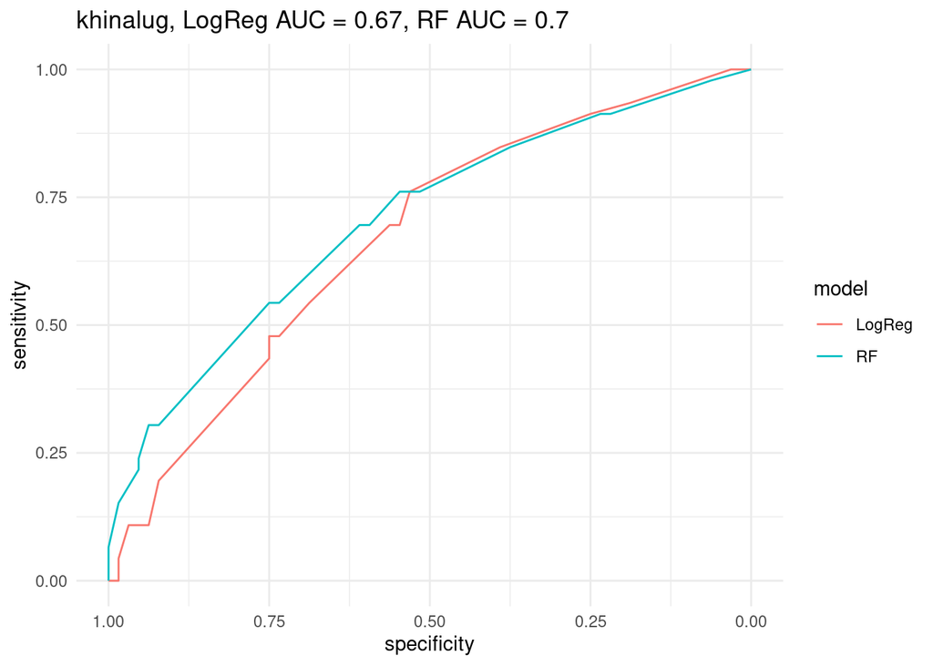

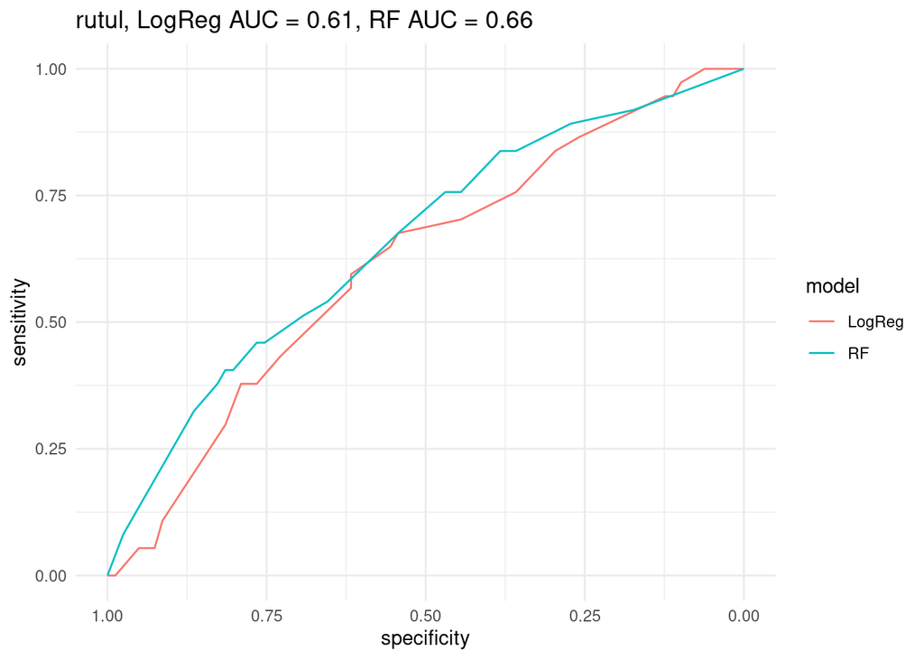

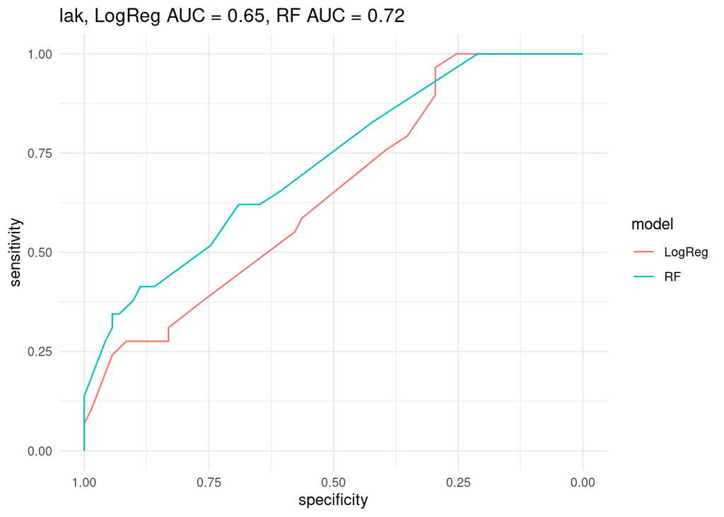

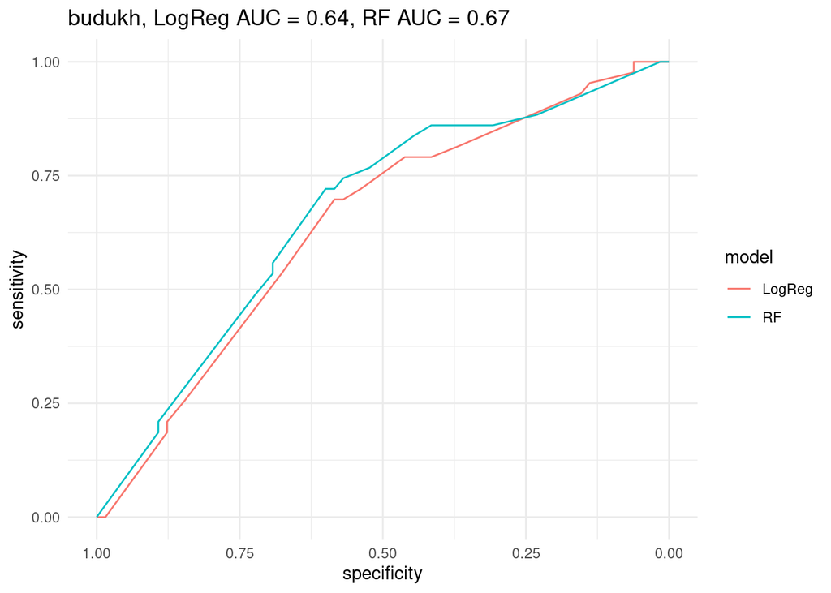

```r
for (lang in unique(data$language)) {
  data %>%
    filter(language == lang) -> df

  names(df) <- str_replace(names(df), " ", "_")

  log.reg <- glm(data=df, as.factor(gender) ~ size + first_ph_class + f_loan,
             family = "binomial")

  predict.log.reg <- predict(log.reg, df, type = "response")

  model.forest <- randomForest(data=df,
                               as.factor(gender) ~ size + first_ph_class + f_loan,
                               importance = TRUE)

  predict.rf <- predict(model.forest, df, type="prob")
  predict.rf <- as_tibble(predict.rf)$`4`

  log.roc_res <- roc(as.numeric(as.factor(df$gender)),
                     predict.log.reg + 1, algorithm=1)

  rf.roc_res <- roc(as.numeric(as.factor(df$gender)),
                    predict.rf + 1, algorithm=1)

  g <- ggroc(list(LogReg=log.roc_res, RF=rf.roc_res)) +
    labs(color="model") +
    theme_minimal() +
    ggtitle(sprintf("%s, LogReg AUC = %s, RF AUC = %s",
                    lang, round(log.roc_res$auc, 2),
                    round(rf.roc_res$auc, 2)))
  plot(g)
}
```